# Analysis of Boston Restaurant Data

Chev Eldrid

April 19, 2019

# Introduction

When this project was announced, I knew I wanted to do something with food. *(Maybe the 11:45 - 1:25 timeslot subconsciously affected my decision, but here we are.)* After thinking it over for a few days, I decided I wanted to see if there was any corrolation between average incomes in Boston neighborhoods and the food offered there. In other words, where people could afford to eat out more - was the average cost of said activity higher?

# Data Collection

For restaurant data, I settled on the [Yelp Fusion API](https://www.yelp.com/developers/documentation/v3). It’s incredibly intuitive to use, and only requires registering your “App” to receive an API key. This is opposed to Google Places that requires a cloud instance and a cloud account with free credits to eventually pull data that costs extra if you want pricing data…it snowballs. Now, the downside of course is for a restaurant to appear in the Yelp data, someone needs to have reviewed it. This does limit the data’s exposure to new establishments but as is this is more of a study on overall behavior of restaurant pricing I believe that’s an issue that could be pushed to a more in-depth analysis down the road.

The other downside to Yelp, is it limits each query to a maximum result list of 1000 entries. So, if I were to try and GET all restaurants in Boston, I would only receive a list of 1000. The way this list is selected isn’t really told to us either, so we have to assume it’s some internal logic that we can’t attribute for. To get around this, I changed my query from GETting all restaurants in Boston, to individual GET requests for every zipcode in the greater Metropolitan area of Boston. Now, there still may be more than 1000 places in each of these locations but once we filtered the resulting 22000 entries for duplicates, our final Boston restaurant listhad around 4,000 entries. a firm upgrade of our original 1000 by 4 fold.

Now, with this “unique-boston-rest.csv” list we need to add a couple more columns necessary for aggregate analysis. Instead of doing this in the Python pull script, I felt it would be easier in R - so here we are re-filtering by the list of Boston area codes (in case the list of any zip included entries from outside townships), and then aggregating data per zip for a median price.

```r
fixed_data <- read_csv("unique-boston-rest.csv")
temp_fixed_data <- data.frame("PriceCount" = fixed_data$PriceCount, "Zip" = fixed_data$Zip)
#filtering for only Boston zips we have income data for
temp_fixed_data <- temp_fixed_data[temp_fixed_data$Zip %in% c("2151","2152","2129","2128","2113","2114","2203","2110","2109","2108","2111","2116","2210","2199","2115","2215","2118","2127","2120","2119","2125","2122","2121","2130","2131","2126","2136","2467","2135","2134","2163"), ]

avg_column <- aggregate(. ~ temp_fixed_data$Zip, temp_fixed_data[-2], median)
median_ratings <- data.frame("Zip" = avg_column$`temp_fixed_data$Zip`, "PriceCount" = avg_column$PriceCount)
write.csv(median_ratings, "zips-and-medians.csv")
```

The data doesn’t make for a very good graphic on its own, but that’s okay. The main use for this segment is to create a new csv called “zips-and-medians.csv” that we’ll pull into QGIS as a feature column for each zip and create a heatmap. More on that below.

For income data, I used city-data.com. While they don’t have an exact trail to where *all* their data comes from, they do reference public datasets and census data as the primary sources for population and income data with the more precise fields coming from commercial sources. There’s no easy way to download the selection specific to boston area zipcodes I wanted, so this was a manual process of copying the data from their website and storing it in a csv to eventually upload into QGIS as another zipcode feature column.

The rest of our data is locations and name fields necessary for identifying the neighborhoods and zipcodes of Boston. The majority come from data.boston.gov, in the form of [zips](https://data.boston.gov/dataset/zip-codes1), [Neighborhoods](https://data.boston.gov/dataset/boston-neighborhoods), and [Colleges](https://data.boston.gov/dataset/colleges-and-universities).

## QGIS

So, here is our first analysis: an overlay of of median restaurant prices per zipcode over a map of Boston with neighborhood names for reference. Blue, means no data could be collected in those areas. Dark purple indicates a median restaurant price of 1 `$` (Below `$`10 for a meal), Pink is an average of 1.5 `$`, and Orange shows a median restaurant price of `$$` (Between `$`11-30, The big times).

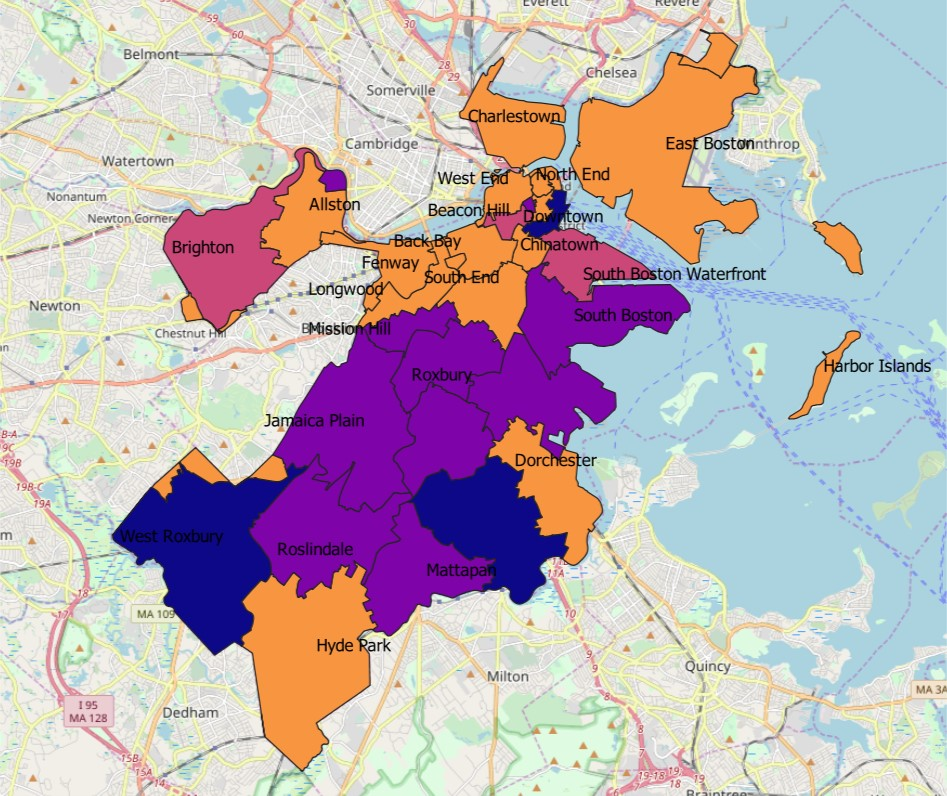

## R Charts

Apart from all the location-based data crunching, there’s also an opportunity to dig through the specific food data aggregating on type as opposed to zipcode.

First, let’s take that same unique restaurant list and create individual restaurant entries for each tag given to describe the establishment. For example, if “Amelia’s Taqueria” is tagged as both “Mexican” and “Tex-Mex”, our resulting dataset will include one entry of Amelia’s with “Mexican” as a tag, and another with “Tex-Mex”. This is the easiest way to count how many times each tag appears throughout Boston without creating incredibly complex array manipulation methods.

```r
fixed_data <- read_csv("unique-boston-rest.csv")
split_cats <- data.frame(row.names = fixed_data[1, ])
#trying some freaky stuff
for(i in 1:nrow(fixed_data)) {
    row <- fixed_data[i,]
    categories <- strsplit(row$Category, ",")[[1]]
    for(j in 1:length(categories)) {
      rowTemp <- data.frame(row$Name, row$Rating, row$Price, row$PriceCount, categories[j], row$Lat, row$Long, row$City, row$Address, row$Zip)
      names(rowTemp)<-c("Name", "Rating", "Price", "PriceCount", "Category", "Lat", "Long", "City", "Address", "Zip")
      split_cats <- rbind(split_cats, rowTemp)
    }
    # do stuff with row
}
```

```r
#split_cats
skinned_cats <- data.frame("PriceCount" = split_cats$PriceCount, "Category" = split_cats$Category)
avg_column <- aggregate(. ~ skinned_cats$Category, skinned_cats[-2], mean)
freq_column <- data.frame(table(skinned_cats$Category))
freq_column <- data.frame("Category" = freq_column$Var1, "Count"=freq_column$Freq)
skinned_cats <- data.frame("Category" = avg_column$`skinned_cats$Category`, "PriceCount" = avg_column$PriceCount, "Mode" = freq_column$Count)
skinned_cats <- skinned_cats[skinned_cats$Mode > 1,]
cheapest_cats <- head(skinned_cats[order(skinned_cats$PriceCount,decreasing=FALSE),], n = 20)
skinned_cats <- head(skinned_cats[order(skinned_cats$PriceCount,decreasing=TRUE),], n = 20)
skinned_cats
```

```
##                   Category PriceCount Mode
## 151            Steakhouses   3.000000   17
## 229          Live/Raw Food   3.000000    2
## 252        Cooking Classes   3.000000    4
## 356         Health Markets   3.000000    3
## 398                Russian   3.000000    2
## 214                 French   2.857143   21
## 287        Modern European   2.800000    5
## 329         Organic Stores   2.714286    7
## 227                 French   2.636364   11
## 246  Venues & Event Spaces   2.636364   11
## 93               Wine Bars   2.603175   63
## 302  Venues & Event Spaces   2.571429    7
## 90                Peruvian   2.500000    2
## 108     Tapas/Small Plates   2.500000    6
## 167    Do-It-Yourself Food   2.500000    2
## 247    Do-It-Yourself Food   2.500000    2
## 255                Izakaya   2.500000    2
## 270              Tea Rooms   2.500000    6
## 296               Wineries   2.500000    2
## 102     Tapas/Small Plates   2.421053   19
```

```r
cheapest_cats
```

```
##                  Category PriceCount Mode
## 36            Food Stands   1.000000    8
## 67                  Kebab   1.000000    2
## 86           Puerto Rican   1.000000    3
## 112          Cheesesteaks   1.000000    5
## 134               Falafel   1.000000    4
## 143           Food Stands   1.000000    6
## 186             Cafeteria   1.000000    3
## 193              Cideries   1.000000    2
## 204               Falafel   1.000000    8
## 206               Waffles   1.000000    2
## 223          Cheesesteaks   1.000000    2
## 225            Shaved Ice   1.000000    2
## 262  Patisserie/Cake Shop   1.000000    2
## 309           Gluten-Free   1.000000    2
## 318 Banks & Credit Unions   1.000000    4
## 368           Trinidadian   1.000000    2
## 371        Internet Cafes   1.000000    2
## 374         Imported Food   1.000000    2
## 146             Fast Food   1.046875   64
## 315                Donuts   1.050000   20
```

Analysis based on avg rating of restuarant categories

```r
skinned_cats <- data.frame("Rating" = split_cats$Rating, "Category" = split_cats$Category)
avg_column <- aggregate(. ~ skinned_cats$Category, skinned_cats[-2], mean)
freq_column <- data.frame(table(skinned_cats$Category))
freq_column <- data.frame("Category" = freq_column$Var1, "Count"=freq_column$Freq)
skinned_cats <- data.frame("Category" = avg_column$`skinned_cats$Category`, "Rating" = avg_column$Rating, "Mode" = freq_column$Count)
skinned_cats <- skinned_cats[skinned_cats$Mode > 5,]
cheapest_cats <- head(skinned_cats[order(skinned_cats$Rating,decreasing=FALSE),], n = 30)
skinned_cats <- head(skinned_cats[order(skinned_cats$Rating,decreasing=TRUE),], n = 30)
skinned_cats
```

```
##                    Category   Rating Mode
## 194            Cheese Shops 4.444444    9
## 126          Specialty Food 4.375000   20
## 216        Fruits & Veggies 4.307692   13
## 198          Farmers Market 4.282609   23
## 297    Chocolatiers & Shops 4.272727   11
## 110         Seafood Markets 4.250000   12
## 182                 African 4.250000    6
## 152         Seafood Markets 4.222222    9
## 130              Meat Shops 4.200000   10
## 56              Pasta Shops 4.187500    8
## 42            Imported Food 4.166667    9
## 169  Food Delivery Services 4.166667    9
## 156              Meat Shops 4.153846   13
## 335            Custom Cakes 4.142857    7
```

[output cut: 16 more lines]

```r
cheapest_cats
```

```
##                       Category   Rating Mode
## 343                 Drugstores 2.366667   15
## 344  Cosmetics & Beauty Supply 2.409091   11
## 146                  Fast Food 2.437500   64
## 20               Chicken Wings 2.603774   53
## 188               Chicken Shop 2.727273   11
## 315                     Donuts 2.900000   20
## 119                     Donuts 3.030303   66
## 128              Chicken Wings 3.071429   21
## 73                   Fast Food 3.075269   93
## 53                     Burgers 3.078512  121
## 218         Convenience Stores 3.096774   31
## 208         Convenience Stores 3.172414   58
## 72                     Burgers 3.187500   56
## 184               Comfort Food 3.250000   12
```

[output cut: 16 more lines]